# Exercise

```python
%matplotlib inline

import pandas as pd
import numpy as np
import matplotlib.pyplot as plt
import seaborn as sns
from random import sample

from itertools import chain
from random import sample
import scipy
```

### Read the Data

```python
data = pd.read_csv('findings_data.csv')
```

```python
data.head()
```

|  | Unnamed: 0 | Patient ID | Finding Labels | Patient Age | Patient Gender | Mass_Size |
| --- | --- | --- | --- | --- | --- | --- |
| 0 | 1 | 1 | Cardiomegaly\|Emphysema | 57 | M | NaN |
| 1 | 2 | 2 | No Finding | 77 | M | NaN |
| 2 | 3 | 3 | Atelectasis | 79 | M | NaN |
| 3 | 4 | 4 | Cardiomegaly\|Edema\|Effusion | 55 | F | NaN |
| 4 | 5 | 5 | Consolidation\|Mass | 68 | M | 2516.0 |

```python
data.info()
```

```
<class 'pandas.core.frame.DataFrame'>
RangeIndex: 999 entries, 0 to 998
Data columns (total 6 columns):
 #   Column          Non-Null Count  Dtype
---  ------          --------------  -----
 0   Unnamed: 0      999 non-null    int64
 1   Patient ID      999 non-null    int64
 2   Finding Labels  999 non-null    object
 3   Patient Age     999 non-null    int64
 4   Patient Gender  999 non-null    object
 5   Mass_Size       35 non-null     float64
dtypes: float64(1), int64(3), object(2)
memory usage: 47.0+ KB
```

### Understand the Distribution

To understand distributions of variables as they relate to diseases, let's try splitting up the 'Finding Labels' column into one additional column per disease (e.g. one for 'Cardiomegaly', one for 'Emphysema', etc.) and put a binary flag in that column to indicate the presence of the disease

```python
all_labels = np.unique(list(chain(*data['Finding Labels'].map(lambda x: x.split('|')).tolist())))
all_labels = [x for x in all_labels if len(x)>0]
print('All Labels ({}): {}'.format(len(all_labels), all_labels))
for c_label in all_labels:
    if len(c_label)>1: # leave out empty labels
        data[c_label] = data['Finding Labels'].map(lambda finding: 1.0 if c_label in finding else 0)
data.sample(3)
```

```
All Labels (14): ['Atelectasis', 'Cardiomegaly', 'Consolidation', 'Edema', 'Effusion', 'Emphysema', 'Fibrosis', 'Infiltration', 'Mass', 'No Finding', 'Nodule', 'Pleural_Thickening', 'Pneumonia', 'Pneumothorax']
```

|  | Unnamed: 0 | Patient ID | Finding Labels | Patient Age | Patient Gender | Mass_Size | Atelectasis | Cardiomegaly | Consolidation | Edema | Effusion | Emphysema | Fibrosis | Infiltration | Mass | No Finding | Nodule | Pleural_Thickening | Pneumonia | Pneumothorax |
| --- | --- | --- | --- | --- | --- | --- | --- | --- | --- | --- | --- | --- | --- | --- | --- | --- | --- | --- | --- | --- |
| 239 | 240 | 240 | No Finding | 62 | M | NaN | 0.0 | 0.0 | 0.0 | 0.0 | 0.0 | 0.0 | 0.0 | 0.0 | 0.0 | 1.0 | 0.0 | 0.0 | 0.0 | 0.0 |
| 935 | 936 | 936 | Atelectasis | 29 | M | NaN | 1.0 | 0.0 | 0.0 | 0.0 | 0.0 | 0.0 | 0.0 | 0.0 | 0.0 | 0.0 | 0.0 | 0.0 | 0.0 | 0.0 |
| 666 | 667 | 667 | No Finding | 52 | F | NaN | 0.0 | 0.0 | 0.0 | 0.0 | 0.0 | 0.0 | 0.0 | 0.0 | 0.0 | 1.0 | 0.0 | 0.0 | 0.0 | 0.0 |

### Your goal is to perform EDA on the population in the dataset such that you can answer the following questions:

1. How are the different diseases distributed in my dataset in terms of frequency and co-occurrence with one another? (For the sake of time, just choose one of the diseases and assess its co-occurrence frequencies with all other diseases.)
2. How is age distributed across my dataset? Is it distributed differently for different diseases?
3. How is sex distributed across my dataset? Is it distributed differently for different diseases? For findings that have a Mass_size (i.e. not just a binary classification of disease presence) is there a relationship between size and age, sex, or presence of other diseases?

### TODO - 1

Now write your code here to visualize some of the distributions specified in the instructions

```
[Text(0, 0.5, 'Number of Images with Lables')]
```

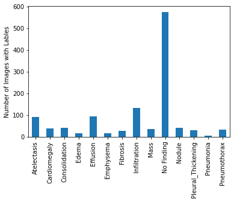

```python
# Write your code here

# Visualizing frequency of each label

freq_plt = data[all_labels].sum().plot(kind='bar')
freq_plt.set(ylabel='Number of Images with Lables')
```

```python
# Frequency count of all the diseases

(data[all_labels].sum()/len(data)) * 100
```

```
Atelectasis            9.309309
Cardiomegaly           3.803804
Consolidation          4.304304
Edema                  1.601602
Effusion               9.509510
Emphysema              1.801802
Fibrosis               2.702703
Infiltration          13.413413
Mass                   3.503504
No Finding            57.557558
Nodule                 4.104104
Pleural_Thickening     3.203203
Pneumonia              0.600601
Pneumothorax           3.303303
dtype: float64
```

### Interpretation

By looking at the above bar plot we can clearly see that most of the images in our dataset have **No Findings**. From the frequency count we can clearly see that 57.5% data is of no significance. Furthermore, by looking at the bar plot we can see that **Infiltration**,**Effusion** and **Atelectasis** are commonly occuring diseases.

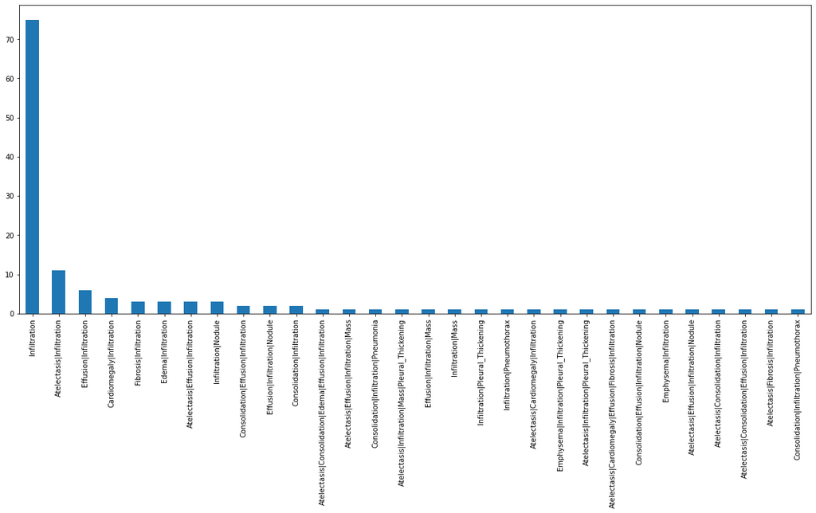

```python
plt.figure(figsize=(20,8))
data[data.Infiltration == 1]['Finding Labels'].value_counts()[:30].plot(kind='bar')
```

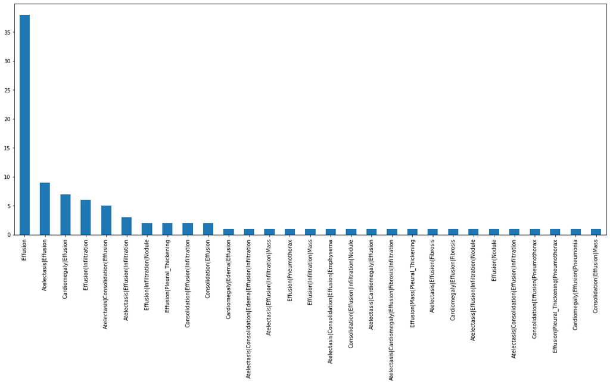

```python
plt.figure(figsize=(20,8))
data[data.Effusion == 1]['Finding Labels'].value_counts()[:30].plot(kind='bar')
```

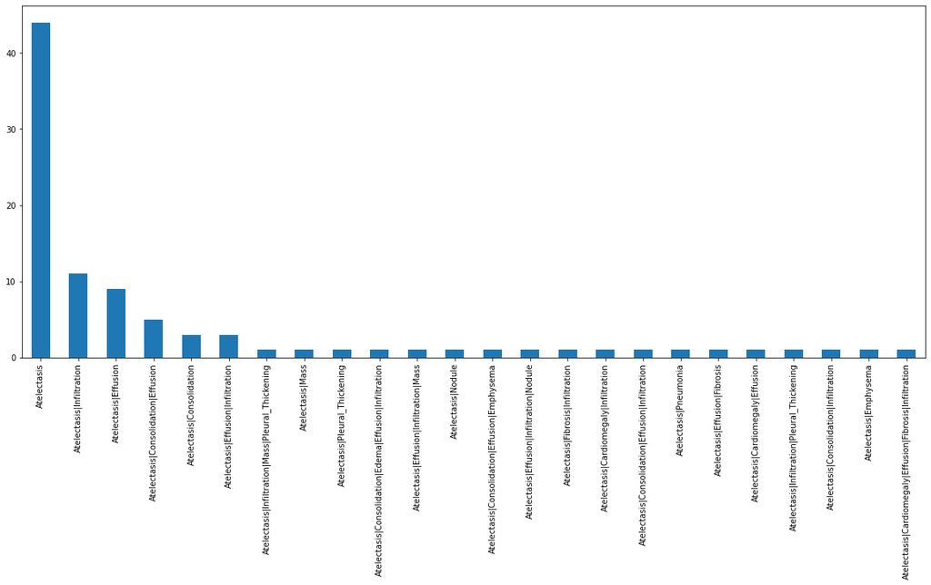

```python
plt.figure(figsize=(20,8))
data[data.Atelectasis == 1]['Finding Labels'].value_counts()[:30].plot(kind='bar')
```

1. How is age distributed across my dataset? Is it distributed differently for different diseases?

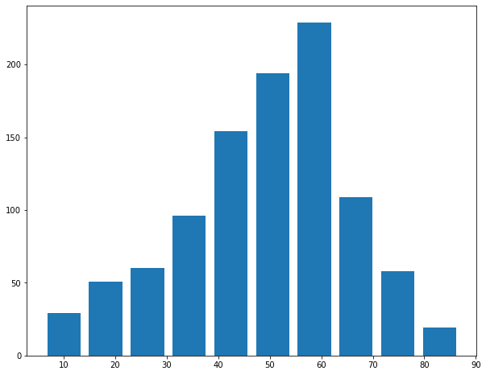

```python
# Distribution of age across population

plt.figure(figsize=(10,8))
plt.hist(data['Patient Age'], rwidth=0.8)
```

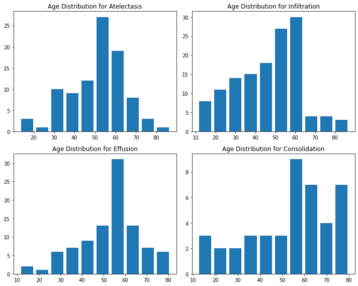

```python
# Distribution of Age Across different diseases

fig, ax = plt.subplots(2,2, figsize=(10,8))

ax[0][0].set_title('Age Distribution for Atelectasis')
ax[0][0].hist(data[data.Atelectasis == 1]['Patient Age'], rwidth=0.8)

ax[0][1].set_title('Age Distribution for Infiltration')
ax[0][1].hist(data[data.Infiltration == 1]['Patient Age'], rwidth=0.8)

ax[1][0].set_title('Age Distribution for Effusion')
ax[1][0].hist(data[data.Effusion == 1]['Patient Age'], rwidth=0.8)

ax[1][1].set_title('Age Distribution for Consolidation')
ax[1][1].hist(data[data.Consolidation == 1]['Patient Age'], rwidth=0.8)

fig.tight_layout()
```

### Interpretation

Form these histograms we can clearly see that most common age when human body faces such abnormalities (diseases) is 50 - 60 years. We can also see that Infiltration can be observed even in younger generations.

1. How is sex distributed across my dataset? Is it distributed differently for different diseases?

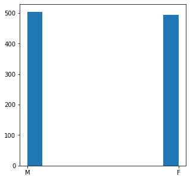

```python
plt.figure(figsize=(5,5))
plt.hist(data['Patient Gender'])
```

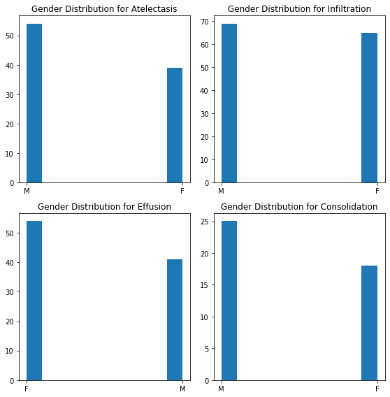

```python
fig, ax = plt.subplots(2,2, figsize=(8,8))

ax[0][0].set_title('Gender Distribution for Atelectasis')
ax[0][0].hist(data[data.Atelectasis == 1]['Patient Gender'])

ax[0][1].set_title('Gender Distribution for Infiltration')
ax[0][1].hist(data[data.Infiltration == 1]['Patient Gender'])

ax[1][0].set_title('Gender Distribution for Effusion')
ax[1][0].hist(data[data.Effusion == 1]['Patient Gender'])

ax[1][1].set_title('Gender Distribution for Consolidation')
ax[1][1].hist(data[data.Consolidation == 1]['Patient Gender'])

fig.tight_layout()
```

1. For findings that have a Mass_size (i.e. not just a binary classification of disease presence) is there a relationship between size and age, sex, or presence of other diseases?

### How age & gender relate to the mass size?

Finally, look at if and how age & gender relate to mass size in individuals who have a mass as a finding:

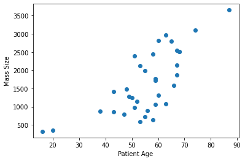

```python
plt.scatter(data['Patient Age'],data['Mass_Size'])
plt.xlabel('Patient Age')
plt.ylabel('Mass Size')
```

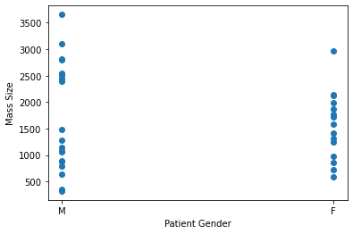

```python
plt.scatter(data['Patient Gender'], data['Mass_Size'])
plt.xlabel('Patient Gender')
plt.ylabel('Mass Size')
```

### TODO - 2

Use the following to see if there are significant correlations between the two:

`scipy.stats.pearsonr(mass_sizes,ages)`  
`scipy.stats.ttest_ind(mass_sizes_male, mass_sizes_female)`

```python
# Write your code here

mass_sizes = data['Mass_Size'].values
mass_inds = np.where(~np.isnan(mass_sizes)) # retrive non-zero indexes
patient_ages = data.iloc[mass_inds]['Patient Age']
mass_sizes = mass_sizes[mass_inds]
scipy.stats.pearsonr(mass_sizes, patient_ages)
```

```
(0.7275663300043572, 7.354553889321959e-07)
```

### From this positive pearson correlation coefficient for mass size and patient age, we can clearly see that, they are highly linearly corelated

```python
# Expected Mass Size for males

np.mean(data[data['Patient Gender'] == 'M']['Mass_Size'])
```

```
1735.7
```

```python
# Expected Mass Size for female

np.mean(data[data['Patient Gender'] == 'F']['Mass_Size'])
```

```
1550.8
```

```python
# Applying T-Test

scipy.stats.ttest_ind(data[data['Patient Gender'] == 'M']['Mass_Size'], data[data['Patient Gender'] == 'F']['Mass_Size'], nan_policy='omit')
```

```
Ttest_indResult(statistic=0.6188395721019645, pvalue=0.5402707532656862)
```

### T-test

T-test is used for acceting/rejecting a null hypothesis.

1. **Null Hypothesis** : Statement that we are trying to prove/disprove by running test
   1. Two samples can come from same population.
   2. Sample is drawn from a probability distribution
2. T-test is specified in terms of test statistics.
3. Test statistics reduces the dataset into one number which is used to accept or reject the hypothesis

**Note:** We can use this test, if we observe two independent samples from the same or different population, e.g. exam scores of boys and girls or of two ethnic groups. The test measures whether the average (expected) value differs significantly across samples. If we observe a large p-value, for example larger than 0.05 or 0.1, then we cannot reject the null hypothesis of identical average scores. If the p-value is smaller than the threshold, e.g. 1%, 5% or 10%, then we reject the null hypothesis of equal averages. [source - https://docs.scipy.org/doc/scipy/reference/generated/scipy.stats.ttest_ind.html]

```python
#
```